# Shiny Part 3: Style

# Preamble

```r
library(shiny)
library(ggplot2)
```

Having covered some of the basics for both the user interface and backend server logic, we will now spend a little bit of time making our apps look fly as hell. This lab will be primarily oriented around the layout of the UI with minimal server logic, but understand that everything from the preceding labs is also applicable here.

## HTML

```r
# UI object created with fluidPage returns HTML code
ui <- fluidPage(
  h3("This is a header"),
  p(style="color:teal;font-size:10px;text-align:center;", "Hey there")
)

# Using print() gives me R output so I can see what it looks like
print(ui)
```

```
## <div class="container-fluid">
##   <h3>This is a header</h3>
##   <p style="color:teal;font-size:10px;text-align:center;">Hey there</p>
## </div>
```

```r
# Without print(), it's raw HTML so R Markdown renders it as such
ui
```

### This is a header

Hey there

Fortunately for us, most of the UI functions we will be using are at a much higher level, requiring basically no knowledge of HTML. It is something worth being aware of, though, in case you ever want to slip in a little of your own design into the Shiny app.

Fun fact: R Studio is also written in HTML. You can right-click anywhere and click “Inspect Element” to verify yourself.

# Lab

This lab will focus on some of the more basic layouts for Shiny applications. There is a lot of information freely available on the web for more intricate designs, including the [layout guide](https://shiny.posit.co/r/articles/build/layout-guide/) provided on the main Shiny website.

## Sidebars

Perhaps the simplest and most common the Shiny layouts is that provided by `sidebarLayout()` which itself takes two components: `sidebarPanel()` and `mainPanel()`. An illustration of how this looks is here:

```r
ui <- fluidPage(

  # A title panel is available for all of the layouts we will use
  titlePanel("Sidebar Layout"),

  sidebarLayout(

    sidebarPanel(
      numericInput("n", label = "Number of obs:", value = 100),
      sliderInput("bins", label = "Number of bins:", min = 2, max = 20, value = 10)
    ),

    mainPanel(
      plotOutput("myhist")
    )
  )
)

server <- function(input, output) {

  n <- reactive(input$n)
  bins <- reactive(input$bins)

  output$myhist <- renderPlot({
    X <- rnorm(n())
    ggplot() + geom_histogram(aes(x = X), bins = bins())
  })
}

shinyApp(ui, server)
```

The trickiest thing about sidebar layouts (and most UI layouts, actually) is the layers of nested parenthesis and commas. Here, careful commenting and liberal spacing will help keep things straight. An infinitely useful trick here is the auto-align shortcut provided by R Studio. Highlight the code you wish to align and use `Ctrl+I` to align it. This happens most frequently when copy and pasting code to move it around, causing the alignment to be off.

**Question 1:** It’s such an important component of keeping your Shiny application sensible that we are going to practice here. Copy this misaligned code to an R Script, auto-align it, then paste it back as your solution

```r
ui <- fluidPage(

   titlePanel("Title"),
       sidebarLayout(
  sidebarPanel(
        numericInput("n", label = "Number of obs:", value = 100),
sliderInput("bins", label = "Number of bins:", min = 2, max = 20, value = 10)

),
   mainPanel(
  plotOutput("myhist")
)
)
)
```

## Column layout

The sidebar layout offered above is really just a fancy implementation of the grid system used by Shiny to organize the user interface. In discussing the grid system, it will be helpful to think of rows and columns. The function `fluidRow()` creates a row of which we can have any number – theoretically, rows could continue infinitely down the page. Within each row, however, we must specify *columns*. Within each row, there are 12 spaces available for columns, and we create columns of however many spaces with the function `column(width, ...)` where `width` is the number of spaces we wish a column to occupy.

In this example, we create a single fluid row with two column entries: the first is of width 4 and contains our input boxes while the second is of width 8, containing our plot. We see that this is nearly identical to the layout we had with `sidebarLayout()`.

```r
ui <- fluidPage(

  titlePanel("Columns and Rows"),

  fluidRow(
    column(4,
           numericInput("n", label = "Number of obs:", value = 100),
           sliderInput("bins", label = "Number of bins:", min = 2, max = 20, value = 10)),
    column(8,
           plotOutput("myhist"))
  )
)

server <- function(input, output) {

  n <- reactive(input$n)
  bins <- reactive(input$bins)

  output$myhist <- renderPlot({
    X <- rnorm(n())
    ggplot() + geom_histogram(aes(x = X), bins = bins())
  })
}

shinyApp(ui, server)
```

In fact, it is *exactly* the sidebar layout if we add the `wellPanel()` around our inputs (`wellPanel()` creates a CSS class around the inputs adding an inset border and gray background)

```r
ui <- fluidPage(

  titlePanel("Columns and Rows"),

  fluidRow(
    column(4,
           wellPanel( # added a well panel (thank goodness for Ctrl+I!)
             numericInput("n", label = "Number of obs:", value = 100),
             sliderInput("bins", label = "Number of bins:", min = 2, max = 20, value = 10)
           )
    ),
    column(8,
           plotOutput("myhist"))
  )
)

server <- function(input, output) {

  n <- reactive(input$n)
  bins <- reactive(input$bins)

  output$myhist <- renderPlot({
    X <- rnorm(n())
    ggplot() + geom_histogram(aes(x = X), bins = bins())
  })
}

shinyApp(ui, server)
```

**Question 2:** Using `fluidRow()` (perhaps multiple times), add the necessary code to reproduce the Shiny app below (don’t worry too much about setting the values of sliders or inputs) (The solution is in a hidden code block below)

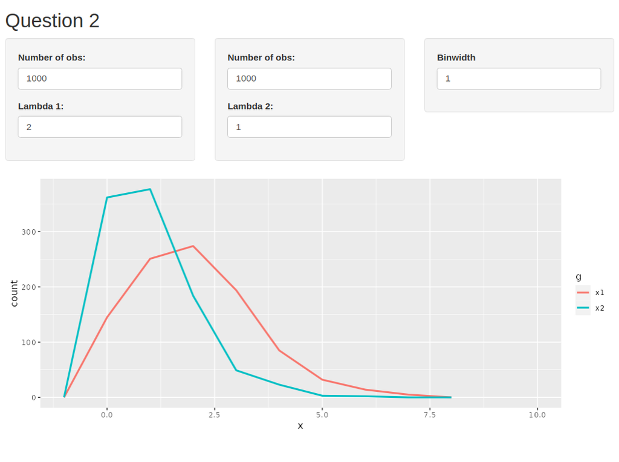

```r
# Function for plot
freqpoly <- function(x1, x2, binwidth = 0.1, xlim = c(-3, 3)) {
  df <- data.frame(
    x = c(x1, x2),
    g = c(rep("x1", length(x1)), rep("x2", length(x2)))
  )

  ggplot(df, aes(x, colour = g)) +
    geom_freqpoly(binwidth = binwidth, linewidth = 1) +
    coord_cartesian(xlim = xlim)
}

ui <- fluidPage(
  # code here
)

server <- function(input, output) {
  output$myplot <- renderPlot({
    x1 <- rpois(input$n1, input$lambda1)
    x2 <- rpois(input$n2, input$lambda2)
    freqpoly(x1, x2, binwidth = input$binwidth, xlim = c(-1, 10))
  }, res = 96)
}

shinyApp(ui, server)
```

```r
# Function for plot
freqpoly <- function(x1, x2, binwidth = 0.1, xlim = c(-3, 3)) {
  df <- data.frame(
    x = c(x1, x2),
    g = c(rep("x1", length(x1)), rep("x2", length(x2)))
  )

  ggplot(df, aes(x, colour = g)) +
    geom_freqpoly(binwidth = binwidth, linewidth = 1) +
    coord_cartesian(xlim = xlim)
}


ui <- fluidPage(
  titlePanel("Question 2"),
  fluidRow(
    column(4,
           wellPanel( # added a well panel (thank goodness for Ctrl+I!)
             numericInput("n1", label = "Number of obs:", value = 1000),
             numericInput("lambda1", label = "Lambda 1:", min = 1, max = 20, value = 1)
           )
    ),
    column(4,
           wellPanel( # added a well panel (thank goodness for Ctrl+I!)
             numericInput("n2", label = "Number of obs:", value = 1000),
             numericInput("lambda2", label = "Lambda 2:", min = 1, max = 20, value = 1)
           )
    ),
    column(4,
           wellPanel(
             numericInput("binwidth", label = "Binwidth", value = 1, min = 1, max = 2)
           ))
  ),
  fluidRow(
    column(12,
           plotOutput("myhist"))
  )

)

server <- function(input, output) {
  output$myhist <- renderPlot({
    x1 <- rpois(input$n1, input$lambda1)
    x2 <- rpois(input$n2, input$lambda2)
    freqpoly(x1, x2, binwidth = input$binwidth, xlim = c(-1, 10))
  }, res = 96)
}

shinyApp(ui, server)
```

## Tabs

Often a convenient way to partition different types of data is with the use of tabs created with `tabsetPanel()`. This pairs particularly well with the use of sidebars

```r
ui <- fluidPage(
  titlePanel("Tabsets"),
  sidebarLayout(
    sidebarPanel(
      numericInput("n", label = "Number of obs:", value = 100),
      sliderInput("bins", label = "Number of bins:", min = 2, max = 20, value = 10)
    ),

    mainPanel(
      # Create tabset with tabesetPanel()
      tabsetPanel(
        # Then each panel gets it own tabPanel
        tabPanel("Tab 1 - Plot",
                 plotOutput("myhist")
                 ),
        tabPanel("Tab 2 - Summary",
                 textOutput("summary"))
      )
    )
  )
)

server <- function(input, output) {

  X <- reactive(rnorm(input$n))
  bins <- reactive(input$bins)

  output$summary <- renderText({
    paste0("The mean of X is: ", round(mean(X()), 4),
           " and the SD is :", round(sd(X()), 4))
  })

  output$myhist <- renderPlot({
    ggplot() + geom_histogram(aes(x = X()), bins = bins())
  })
}

shinyApp(ui, server)
```

Of course, we don’t have to use sidebar, and the tabset is not limited to just being output – you are free to make your Shiny app as complicated as you would like.

```r
ui <- fluidPage(

  titlePanel("Columns and Rows"),

  fluidRow(
    column(4,
           tabsetPanel(
             tabPanel("Choose N: ",
                      wellPanel(
                        numericInput("n", label = "Number of obs:", value = 100))),
             tabPanel("Choose Bins:",
                      wellPanel(
                        sliderInput("bins", label = "Number of bins:", min = 2, max = 20, value = 10)
                      )))),
    column(8, plotOutput("myhist"))),
  fluidRow(column(12, textOutput("summary")))
)


server <- function(input, output) {

  X <- reactive(rnorm(input$n))
  bins <- reactive(input$bins)

  output$summary <- renderText({
    paste0("The mean of X is: ", round(mean(X()), 4),
           " and the SD is :", round(sd(X()), 4))
  })

  output$myhist <- renderPlot({
    ggplot() + geom_histogram(aes(x = X()), bins = bins())
  })
}


shinyApp(ui, server)
```

The only important thing is that you have fun.

## Miscellaneous

Here are a few odds and ends that are worth knowing but are not mission critical

### Navigation Panels

While there is a tremendous number of options remaining for you to explore, I’ll point out two more here briefly – these are the navigation panels and the navigation pages, each of which works similarly to the tabset panels.

Here, for example, we have them as side panels instead of tabs:

```r
ui <- fluidPage(

  titlePanel("Navlist panels"),

  navlistPanel(
    "Header A",
    tabPanel("Component 1", {
      numericInput("n", label = "Number of obs:", value = 100)
    }),
    tabPanel("Component 2", "empty"),
    "Header B",
    tabPanel("Component 3", "empty"),
    tabPanel("Component 4", "empty")
  )
)

server <- function(input, output) {}

shinyApp(ui, server)
```

### Navbar Pages

Alternatively, you can have navigation as pages at the top, though critically, note that this is made with `navbarPage()` rather than `fluidPage()` that we have used in everything thus far. I think these tend to look a little cleaner than the panels:

```r
## Here it is navbarPage instead
ui <- navbarPage("My Application",
  tabPanel("Component 1",

           # We just contain all of this within tabPanel 1
           sidebarLayout(

             sidebarPanel(
               numericInput("n", label = "Number of obs:", value = 100),
               sliderInput("bins", label = "Number of bins:", min = 2, max = 20, value = 10)
             ),

             mainPanel(
               plotOutput("myhist")
             )
           )

           ),
  tabPanel("Component 2", "empty"),
  tabPanel("Component 3", "also empty")
)
server <- function(input, output) {

  n <- reactive(input$n)
  bins <- reactive(input$bins)

  output$myhist <- renderPlot({
    X <- rnorm(n())
    ggplot() + geom_histogram(aes(x = X), bins = bins())
  })
}
shinyApp(ui, server)
```

### Simplifying UI

As we mentioned at the very beginning of this lab, all of the objects returned by the UI (and consequently, each of the functions used in the UI) return some form of HTML. This means that it’s not *strictly* necessary that all of your UI code is written in the UI function. Consider the following

```r
# Define my sidebar outside of the UI
mySidebar <- sidebarLayout(
  sidebarPanel(
    numericInput("n", label = "Number of obs:", value = 100),
    sliderInput("bins", label = "Number of bins:", min = 2, max = 20, value = 10)
  ),
  mainPanel(
    plotOutput("myhist")
  )
)

ui <- fluidPage(
  # This is defined elsewhere
  mySidebar
)

server <- function(input, output) {
  output$myhist <- renderPlot({
    ggplot() + geom_histogram(aes(x = rnorm(input$n)), bins = input$bins)
  })
}

shinyApp(ui, server)
```

I don’t immediately recommend doing this with your code as it can be increasingly more difficult to identify where things are located, to troubleshoot, or make modifications as necessary. However, if you have an app that uses several different tabsets or the navigation pages, it could be helpful to include relevant code together. A common way this is done involves creating R script files for each tab containing all of the relevant code and then using `source()` to read it in at the beginning. For example, if we had written code for navbar pages 1 and 2 and saved them in `navbar1.R` and `navbar2.R`, respectively, our resulting app may look like this:

```r
# This won't work so don't try and run it.

# This reads in any R code from these files and evaluates it
source("navbar1.R")
source("navbar2.R")

ui <- navbarPage("My Application",
  tabPanel("Component 1", navbar1_object),
  tabPanel("Component 2", navbar2_object),
)
server <- function(input, output) {
  # backend code
}
shinyApp(ui, server)
```